# NBA Project

Ilya Kukovitskiy

April 30, 2018

```r
set.seed(1)
library(tree)
library(randomForest)
library(gbm)
```

```r
library(ggplot2)
```

## Data Preprocessing

Reading in and storing dataset from file

```r
d <- read.csv("nbasample2GrpPlus0429.csv",header=T, sep=",")
```

Removing ax_ and la_ variales, as requested

```r
a <- colnames(d)
AX <- grepl("ax_",a) #seeing which values have prefix ax_
AXN <- c() #creating temporary vector recording positions
for(i in 1:length(a)){ #getting rejected values
  if(AX[i]){
    AXN <- c(AXN,i)
  }
}
d <- d[,-AXN] #removing rejected values
a <- colnames(d)
LA <- grepl("la_",a)
LAN <- c() #creating temporary vector recording positions
for(i in 1:length(a)){ #getting rejected values
  if(LA[i]){
    LAN <- c(LAN,i)
  }
}
d <- d[,-LAN] #removing rejected values
a <- colnames(d)
#Cleaning up Environment
rm(AX,AXN,LA,LAN)
```

Removing other Variables

```r
#closest_arena and closest_team are identical - removing closest_arena
x <- match("closest_arena",a)
#x
d <- d[,-x]
a <- colnames(d)
#match("closest_arena",a) #successfully removed

#names(Filter(is.factor, d)) #taking a look at which variables have factors - tree() can only handle 32 levels on factor predictors

#zip_team and zip_arena have 56 levels - too many to grow trees on - removing both
x <- match(c("zip_team","zip_arena"),a)
#x
d <- d[,-x]
a <- colnames(d)
#match(c("zip_team","zip_arena"),a) #successfully removed
#email_domain has 1468 levels - too many.. -removing
x <- match(c("email_domain"),a)
#x
d <- d[,-x]
a <- colnames(d)
#match(c("email_domain"),a) #successfully removed
#source_date has 3773 levels - too many.. -removing
x <- match(c("source_date"),a)
#x
d <- d[,-x]
a <- colnames(d)
#match(c("source_date"),a) #successfully removed
```

**Making a training/test set vector**

```r
train <- sample(1:nrow(d), nrow(d)*(.8))
```

**Viewing Response Variables**

```r
POST <- grepl("post_",a)
POSTN <- c()
for(i in 1:length(a)){ #getting rejected values
  if(POST[i]){
    POSTN <- c(POSTN,i)
  }
}
#POSTN
a[POSTN]
```

```
##  [1] "post_ticket_response"        "post_tickets_flag"
##  [3] "post_total_ticket_amt"       "post_total_tickets"
##  [5] "post_avg_ticket_price"       "post_regular_season_tix"
##  [7] "post_playoffs_tix"           "post_arc_flag"
##  [9] "post_tmc_flag"               "post_tmc_resale_flag"
## [11] "post_vtx_flag"               "post_vtx_flash_flag"
## [13] "post_ticket_package_arc"     "post_ticket_package_derived"
## [15] "post_total_tickets_cat"
```

## Given this dataset, a few useful questions can be answered:

**A** - Who buys tickets? Successful or unsuccessful marketting strategies can be identified.

**B** - How many tickets do people buy? Besides success of strategy; if a person is likely to buy more tickets than they have purchased, they can likely be sold more tickets.

**C** - How much money do people spend on tickets? Same rationale as B, but with dollar-value rather than number of games.

**D** - Who buys tickets at which price? Better seats can be marketted more to those who are more likely to buy them.

### A - Who buys tickets?

Creating matrix to record model type and effectiveness

```r
A_methods <- matrix(c("",""),
                    nrow=1,
                    ncol=2)
colnames(A_methods) <- c("Method","Accuracy")
```

Removing other response variables besides post_tickets_flag

```r
Q <- match('post_tickets_flag',a)
a[Q]
```

```
## [1] "post_tickets_flag"
```

```r
POSTN_ptf <- POSTN[! POSTN %in% Q]
#POSTN_ptf
a[POSTN_ptf]
```

```
##  [1] "post_ticket_response"        "post_total_ticket_amt"
##  [3] "post_total_tickets"          "post_avg_ticket_price"
##  [5] "post_regular_season_tix"     "post_playoffs_tix"
##  [7] "post_arc_flag"               "post_tmc_flag"
##  [9] "post_tmc_resale_flag"        "post_vtx_flag"
## [11] "post_vtx_flash_flag"         "post_ticket_package_arc"
## [13] "post_ticket_package_derived" "post_total_tickets_cat"
```

```r
dataset.ptf <- d[,-POSTN_ptf]
```

```r
attach(dataset.ptf)
```

**Growing Trees** Creating pure Classification Response Vector

```r
#Finding response vector
a.ptf <- colnames(dataset.ptf)
resp.ptf <- grepl("post_",a.ptf)
for(i in 1:length(a.ptf)){
  if(resp.ptf[i]){
    R <- i
  }
}
a.ptf[R]
```

```
## [1] "post_tickets_flag"
```

```r
#Converting it to a yes/no factor
y <- post_tickets_flag
Ticket <- ifelse(y<0.5,"No","Yes")
dataset.ptf[,R] <- Ticket
dataset.ptf[,R] <- factor(dataset.ptf[,R])
```

```r
attach(dataset.ptf)
#Cleaning up environment space (keeping y as is for creaing boosted tree)
rm(Ticket)
```

Growing Preliminary Classification Tree

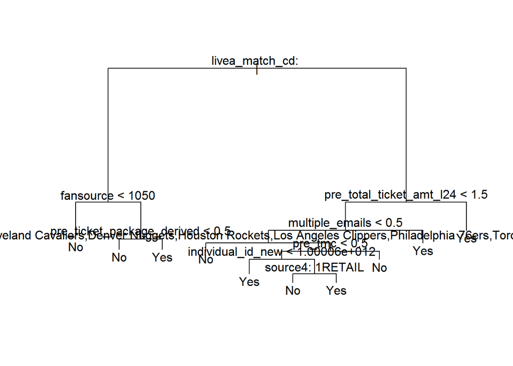

```r
#Growing Tree
tree.ptf <- tree(post_tickets_flag~., dataset.ptf)
#Plotting Tree
plot(tree.ptf)
text(tree.ptf,pretty=0)
```

Estimate and Record Error Rate on (extremely similar) Trained Tree

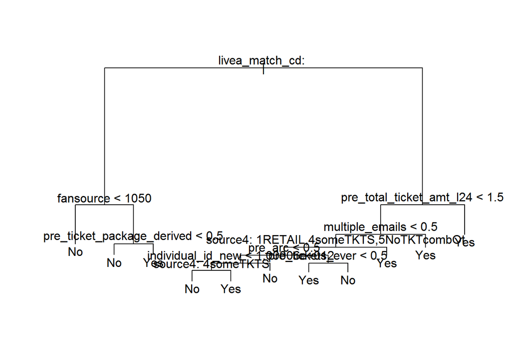

```r
#Growing Tree
tree.ptf_train <- tree(post_tickets_flag~., dataset.ptf, subset=train)
#Plotting Tree
plot(tree.ptf_train)
text(tree.ptf_train,pretty=0)
```

```r
#Fitting model on test set
tree.ptf_pred <- predict(tree.ptf_train, dataset.ptf[-train,], type="class")
#Confusion Matrix
M <- table(tree.ptf_pred, post_tickets_flag[-train])
M
```

```
##
## tree.ptf_pred  No Yes
##           No  901 148
##           Yes  93 858
```

```r
A_methods <- rbind(A_methods, c("Tree",(1-(M[1,2]+M[2,1])/(sum(M)))))
```

```
## [1] "The test error rate is 0.1205"
```

Pruning the Tree

```r
#Cross Validating Tree
cv.ptf_train <- cv.tree(tree.ptf_train, FUN=prune.misclass)
#Looking for best parameter
cv.ptf_train
```

```
## $size
## [1] 11  9  8  4  2  1
##
## $dev
## [1]  975 1093 1308 1399 1475 3579
##
## $k
## [1]    -Inf   57.50   69.00   73.75   80.50 2104.00
##
## $method
## [1] "misclass"
##
## attr(,"class")
## [1] "prune"         "tree.sequence"
```

```r
b <- which.min(cv.ptf_train$dev)
Best <- cv.ptf_train$size[b]
```

```
## [1] "The best trees seem to be of size 11 with cross-validation error of 975"
```

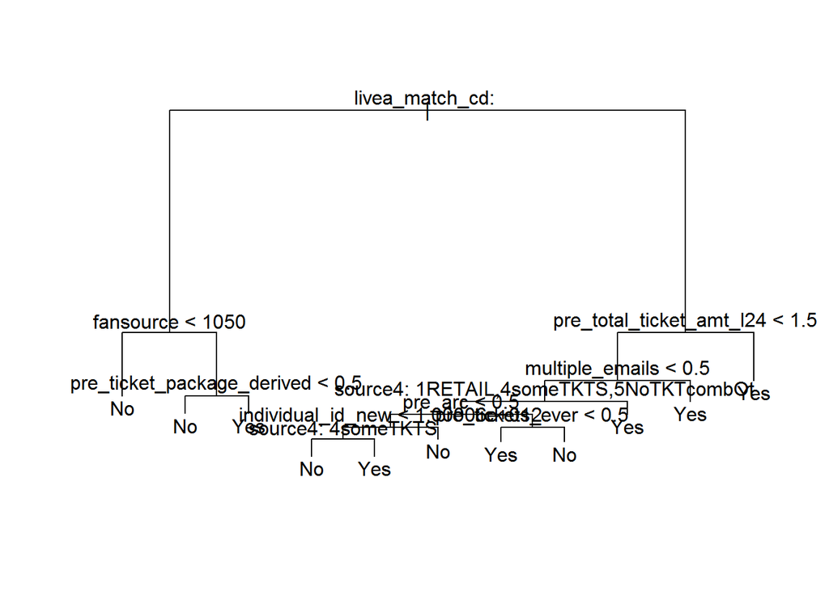

```r
#Pruning tree according to this
prune.ptf_train <- prune.misclass(tree.ptf_train, best=Best)
#Plotting Tree
plot(prune.ptf_train)
text(prune.ptf_train,pretty=0)
```

```r
#Fitting model on test set
prune.ptf_pred <- predict(prune.ptf_train, dataset.ptf[-train,], type="class")
#Confusion Matrix
M_prune <- table(prune.ptf_pred, post_tickets_flag[-train])
M_prune
```

```
##
## prune.ptf_pred  No Yes
##            No  901 148
##            Yes  93 858
```

```r
A_methods <- rbind(A_methods, c('Cross Validated Tree',(1-(M_prune[1,2]+M_prune[2,1])/(sum(M_prune)))))
```

```
## [1] "The test error rate is 0.1205"
```

```
## [1] "Same error rate."
```

Creating Bagged Tree

```r
#Creating a modified dataset - na values are not accepted in bagged trees
dataset.ptf0 <- dataset.ptf
dataset.ptf0[is.na(dataset.ptf0)] <- 0
```

```r
attach(dataset.ptf0)
```

```r
#Growing Tree
bag.ptf_train <- randomForest(post_tickets_flag~., data=dataset.ptf0, subset=train, mtry=ncol(dataset.ptf0)-1, ntrees=1000, importance=TRUE)
#Can't plot tree
#Fitting tree on test set
bag.ptf_pred <- predict(bag.ptf_train, dataset.ptf0[-train,], type="class")
#Confusion Matrix
M_bag <- table(bag.ptf_pred, post_tickets_flag[-train])
M_bag
```

```
##
## bag.ptf_pred  No Yes
##          No  881  90
##          Yes 113 916
```

```r
A_methods <- rbind(A_methods, c('Bagged Tree',(1-(M_bag[1,2]+M_bag[2,1])/(sum(M_bag)))))
```

```
## [1] "The test error rate is 0.1015"
```

```
## [1] "About 90% accurate!"
```

Looking at Predictor Importance

```r
bag.I <- importance(bag.ptf_train)
bag.I <- bag.I[ order(bag.I[,3],decreasing=TRUE), ]
```

```
## [1] "The fifteen most important predictors (by error) according to this model are as follows:"
```

```r
bag.I[1:15,] #includes variable 'tenure' - is this to be removed from this dataset as well?
```

```
##                                  No         Yes MeanDecreaseAccuracy
## livea_match_cd             75.17985 143.7466618            102.08917
## multiple_emails            73.42160  61.7100075             90.40405
## individual_id_new          69.22972  20.5441986             76.47259
## fansource                  67.63132  34.5012216             74.14815
## pre_ticket_package_derived 54.43818  42.6228591             60.81960
## pre_total_ticket_amt_l24   15.89687  27.6934349             28.27767
## pre_tmc                    29.58063   9.0105793             28.03816
## zip_code                   13.24718  20.6819312             26.56142
## agecat                     25.57066   3.0907834             25.89703
## pre_total_ticket_amt_l36   20.59177  20.6704607             25.71584
## closest_arena_distance     16.41883  18.1777106             25.40917
## closeteam                  38.80255  -0.4406122             25.35390
## closest_team               35.72005   0.3578906             24.37412
## tenure                     38.01633 -12.2994680             24.09423
## Team                       38.91309  -0.4907687             23.98719
##                            MeanDecreaseGini
## livea_match_cd                   1543.29606
## multiple_emails                   123.74787
## individual_id_new                 290.74053
## fansource                         212.51842
## pre_ticket_package_derived        277.18122
## pre_total_ticket_amt_l24           89.19680
## pre_tmc                           109.52302
## zip_code                           91.68983
## agecat                             40.79445
## pre_total_ticket_amt_l36           67.63627
## closest_arena_distance            144.38831
## closeteam                         117.01979
## closest_team                      118.78998
## tenure                            147.57536
## Team                              116.08163
```

```r
bag.I <- bag.I[ order(bag.I[,4],decreasing=TRUE), ]
```

```
## [1] "The fifteen most important predictors (by Gini index) according to this model are as follows:"
```

```r
bag.I[1:15,]
```

```
##                                  No         Yes MeanDecreaseAccuracy
## livea_match_cd             75.17985 143.7466618            102.08917
## individual_id_new          69.22972  20.5441986             76.47259
## pre_ticket_package_derived 54.43818  42.6228591             60.81960
## fansource                  67.63132  34.5012216             74.14815
## tenure                     38.01633 -12.2994680             24.09423
## closest_arena_distance     16.41883  18.1777106             25.40917
## multiple_emails            73.42160  61.7100075             90.40405
## closest_team               35.72005   0.3578906             24.37412
## closeteam                  38.80255  -0.4406122             25.35390
## Team                       38.91309  -0.4907687             23.98719
## pre_tmc                    29.58063   9.0105793             28.03816
## zip_code                   13.24718  20.6819312             26.56142
## pre_total_ticket_amt_l24   15.89687  27.6934349             28.27767
## pre_total_ticket_amt_l36   20.59177  20.6704607             25.71584
## pre_total_tickets_l24      13.37717  20.1920414             20.50801
##                            MeanDecreaseGini
## livea_match_cd                   1543.29606
## individual_id_new                 290.74053
## pre_ticket_package_derived        277.18122
## fansource                         212.51842
## tenure                            147.57536
## closest_arena_distance            144.38831
## multiple_emails                   123.74787
## closest_team                      118.78998
## closeteam                         117.01979
## Team                              116.08163
## pre_tmc                           109.52302
## zip_code                           91.68983
## pre_total_ticket_amt_l24           89.19680
## pre_total_ticket_amt_l36           67.63627
## pre_total_tickets_l24              61.30746
```

Creating Random Forest Tree

```r
#Growing Tree
RF.ptf_train <- randomForest(post_tickets_flag~., data=dataset.ptf0, subset=train, ntrees=1000, importance=TRUE)
#Can't plot tree
#Fitting model on test set
RF.ptf_pred <- predict(RF.ptf_train, dataset.ptf0[-train,], type="class")
#Confusion Matrix
M_RF <- table(RF.ptf_pred, post_tickets_flag[-train])
M_RF
```

```
##
## RF.ptf_pred  No Yes
##         No  870  57
##         Yes 124 949
```

```r
A_methods <- rbind(A_methods, c('Random Forest Tree',(1-(M_RF[1,2]+M_bag[2,1])/(sum(M_RF)))))
```

[output not shown]

```
## [1] "More than 90% accurate!"
```

Looking at Predictor Importance

```r
RF.I <- importance(RF.ptf_train)
RF.I <- RF.I[ order(RF.I[,3],decreasing=TRUE), ]
```

```
## [1] "The fifteen most important predictors (by error) according to this model are as follows:"
```

```r
RF.I[1:15,]
```

```
##                                 No        Yes MeanDecreaseAccuracy
## livea_match_cd           42.228246  44.684126             47.07024
## multiple_emails          29.668165  38.167227             37.40318
## individual_id_new        26.691286  32.726671             31.19541
## closeteam                38.399946 -14.659979             25.62129
## closest_team             39.383577 -13.121204             25.19247
## fansource                19.783370  21.625172             24.44881
## Team                     36.439361 -14.119365             24.31604
## tenure                   23.774787  -6.706960             21.70614
## zip_code                 16.792508   9.570484             21.53381
## closest_arena_distance   15.820300  10.627551             19.77468
## pre_arc                  15.721207  19.152875             18.60875
## source4                  18.643692   7.981662             18.60662
## pre_tmc                  16.129192  11.105331             18.55371
## agecat                   15.932942   4.285244             16.38365
## pre_total_ticket_amt_l24  6.354642  20.841383             15.54312
##                          MeanDecreaseGini
## livea_match_cd                  477.02364
## multiple_emails                 144.49416
## individual_id_new               248.10846
## closeteam                       128.41604
## closest_team                    127.17611
## fansource                       284.86497
## Team                            124.41620
## tenure                          105.06359
## zip_code                         68.98795
## closest_arena_distance           78.57637
## pre_arc                         213.42472
## source4                         212.31078
## pre_tmc                          42.62491
## agecat                           50.10372
## pre_total_ticket_amt_l24         73.23426
```

```r
RF.I <- RF.I[ order(RF.I[,4],decreasing=TRUE), ]
```

```
## [1] "The fifteen most important predictors (by Gini index) according to this model are as follows:"
```

```r
RF.I[1:15,]
```

```
##                                 No        Yes MeanDecreaseAccuracy
## livea_match_cd           42.228246  44.684126             47.07024
## fansource                19.783370  21.625172             24.44881
## individual_id_new        26.691286  32.726671             31.19541
## pre_arc                  15.721207  19.152875             18.60875
## source4                  18.643692   7.981662             18.60662
## multiple_emails          29.668165  38.167227             37.40318
## pre_total_ticket_amt_l36  8.890193  17.794637             14.65141
## closeteam                38.399946 -14.659979             25.62129
## closest_team             39.383577 -13.121204             25.19247
## Team                     36.439361 -14.119365             24.31604
## pre_total_tickets_cat     8.855882   8.911857             10.23351
## pre_total_tickets         9.292206  12.446478             12.25065
## tenure                   23.774787  -6.706960             21.70614
## pre_total_tickets_l36     9.262595  11.872385             12.42088
## closest_arena_distance   15.820300  10.627551             19.77468
##                          MeanDecreaseGini
## livea_match_cd                  477.02364
## fansource                       284.86497
## individual_id_new               248.10846
## pre_arc                         213.42472
## source4                         212.31078
## multiple_emails                 144.49416
## pre_total_ticket_amt_l36        131.12625
## closeteam                       128.41604
## closest_team                    127.17611
## Team                            124.41620
## pre_total_tickets_cat           109.35496
## pre_total_tickets               105.77790
## tenure                          105.06359
## pre_total_tickets_l36            96.66739
## closest_arena_distance           78.57637
```

Creating a Boosted Tree

```r
#Creating a modified dataset - columns with no variation are not accepted in boosted trees
dataset.ptfB <- dataset.ptf
colnames(dataset.ptfB)[c(36,56)]
```

```
## [1] "ind_events_allstar_1y" "pre_pac"
```

```r
dataset.ptfB <- dataset.ptfB[,-c(36,56)]
```

```r
attach(dataset.ptfB)
```

```r
#Modify response variable
dataset.ptfB$post_tickets_flag <- y
#distribution='bernoulli' requires 0,1 variable
#Growing Tree
boost.ptf_train <- gbm(post_tickets_flag~., data=dataset.ptfB[train,], distribution='bernoulli', n.trees=1000, interaction.depth=4)
#Can't plot tree
#Fitting model on test set
boost.ptf_pred <- predict(boost.ptf_train, dataset.ptfB[-train,], n.trees=1000)
#Confusion Matrix
M_boost <- table(boost.ptf_pred, post_tickets_flag[-train])
A_methods <- rbind(A_methods, c('Boosted Tree',(1-(M_boost[1,2]+M_boost[2,1])/(sum(M_boost)))))
```

```
## [1] "The test error rate is 0.097"
```

```
## [1] "A bit worse, but still above 90% accuracy!"
```

Looking at Most Effective Method

```r
A_methods <- A_methods[-1,]
A_methods[order(A_methods[,2],decreasing = TRUE),]
```

```
##      Method                 Accuracy
## [1,] "Random Forest Tree"   "0.915"
## [2,] "Boosted Tree"         "0.903"
## [3,] "Bagged Tree"          "0.8985"
## [4,] "Tree"                 "0.8795"
## [5,] "Cross Validated Tree" "0.8795"
```

```r
Top <- A_methods[1,]
```

[output not shown]

Back to top

### B - How many tickets do people buy?

Removing other response variables besides post_total_tickets

```r
Q <- match('post_total_tickets',a)
a[Q]
```

```
## [1] "post_total_tickets"
```

```r
POSTN_ptt <- POSTN[! POSTN %in% Q]
#POSTN_ptt
a[POSTN_ptt]
```

```
##  [1] "post_ticket_response"        "post_tickets_flag"
##  [3] "post_total_ticket_amt"       "post_avg_ticket_price"
##  [5] "post_regular_season_tix"     "post_playoffs_tix"
##  [7] "post_arc_flag"               "post_tmc_flag"
##  [9] "post_tmc_resale_flag"        "post_vtx_flag"
## [11] "post_vtx_flash_flag"         "post_ticket_package_arc"
## [13] "post_ticket_package_derived" "post_total_tickets_cat"
```

```r
dataset.ptt <- d[,-POSTN_ptt]
```

```r
attach(dataset.ptt)
```

Looking at distribution of test responst variable

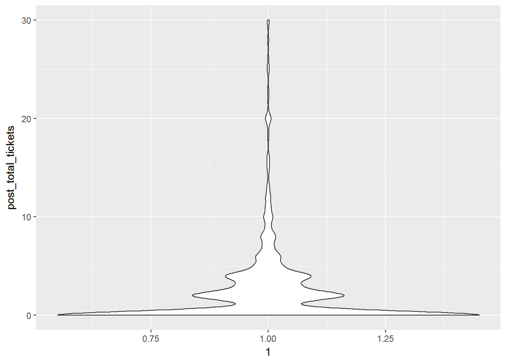

```r
#Creating Violin Plot
p <- ggplot(dataset.ptt[-train,], aes(y=post_total_tickets, 1))
p + geom_violin()
```

```r
#Finding Number of Zeroes
O <- table(post_total_tickets[-train]==0)
#O[2]
```

```
## [1] "0.497 of the values are zeroes."
```

**Growing Trees**

Growing Preliminary Regression Tree

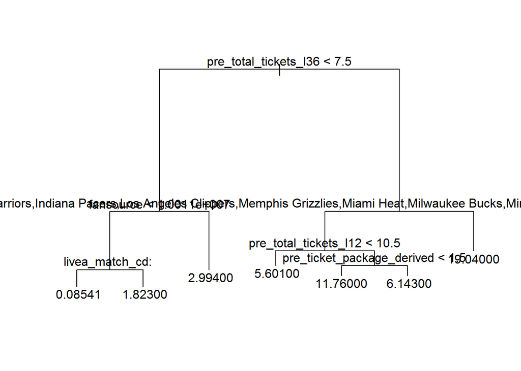

```r
#Growing Tree
tree.ptt <- tree(post_total_tickets~., dataset.ptt)
#Plotting Tree
plot(tree.ptt)
text(tree.ptt,pretty=0)
```

Estimate MSE on (extremely similar) Trained Tree

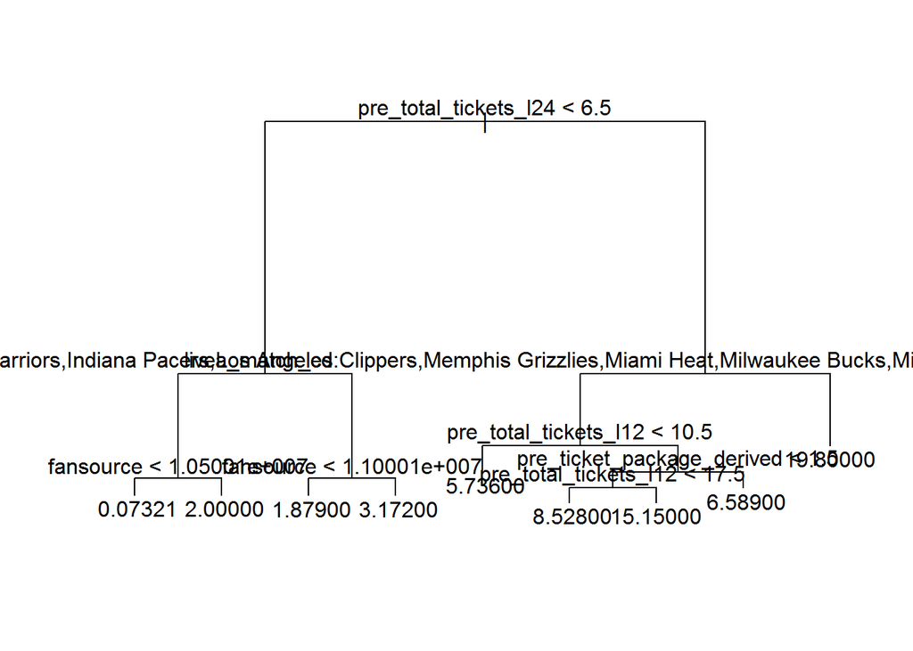

```r
#Growing Tree
tree.ptt_train <- tree(post_total_tickets~., dataset.ptt, subset=train)
#Plotting Tree
plot(tree.ptt_train)
text(tree.ptt_train,pretty=0)
```

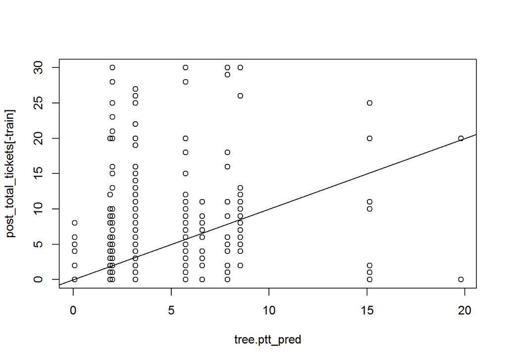

```r
#Fitting model on test set
tree.ptt_pred <- predict(tree.ptt_train, dataset.ptt[-train,])
plot(tree.ptt_pred, post_total_tickets[-train])
abline(0,1)
```

```r
#Mean Squared Error
MSE.ptt <- mean((tree.ptt_pred-post_total_tickets[-train])^2)
MSE.ptt
```

```
## [1] 11.83655
```

```r
A_methods <- rbind(A_methods, c('Tree',MSE.ptt))
```

```
## [1] "Test MSE is 11.8365472502529 . Root MSE is 3.44042835272774 , indicating this model leads to test predictions within around 3.44 total tickets purchased."
```

Pruning the Tree

```r
#Cross Validating Tree
cv.ptt_train <- cv.tree(tree.ptt_train, FUN=prune.tree)
#Finding best paramater to prune
cv.ptt_train
```

```
## $size
## [1] 9 8 7 6 5 4 3 2 1
##
## $dev
## [1]  70681.97  71144.28  71838.34  71624.94  71624.94  73502.06  81772.16
## [8]  87671.40 110500.27
##
## $k
## [1]      -Inf  1242.559  1336.986  1414.245  1445.102  2245.138  6071.890
## [8]  8839.179 21258.429
##
## $method
## [1] "deviance"
##
## attr(,"class")
## [1] "prune"         "tree.sequence"
```

```r
b <- which.min(cv.ptt_train$dev)
Best <- cv.ptt_train$size[b]
```

```
## [1] "The best trees seem to be of size 9 with deviation of 70681.969603896 ."
```

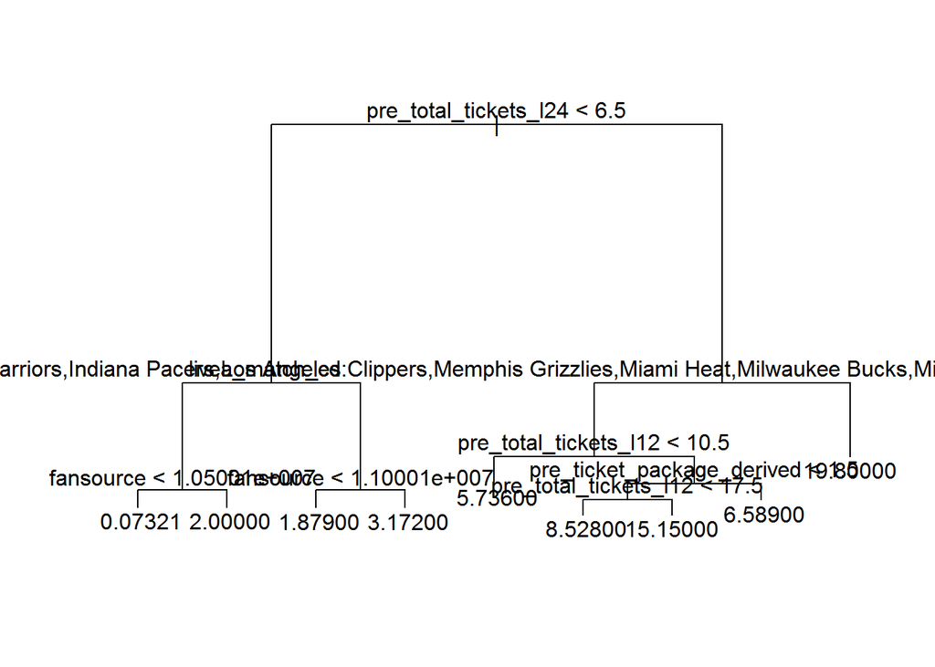

```r
#Pruning Tree according to this
prune.ptt_train <- prune.tree(tree.ptt_train, best=Best)
#Plotting Tree
plot(prune.ptt_train)
text(prune.ptt_train,pretty=0)
```

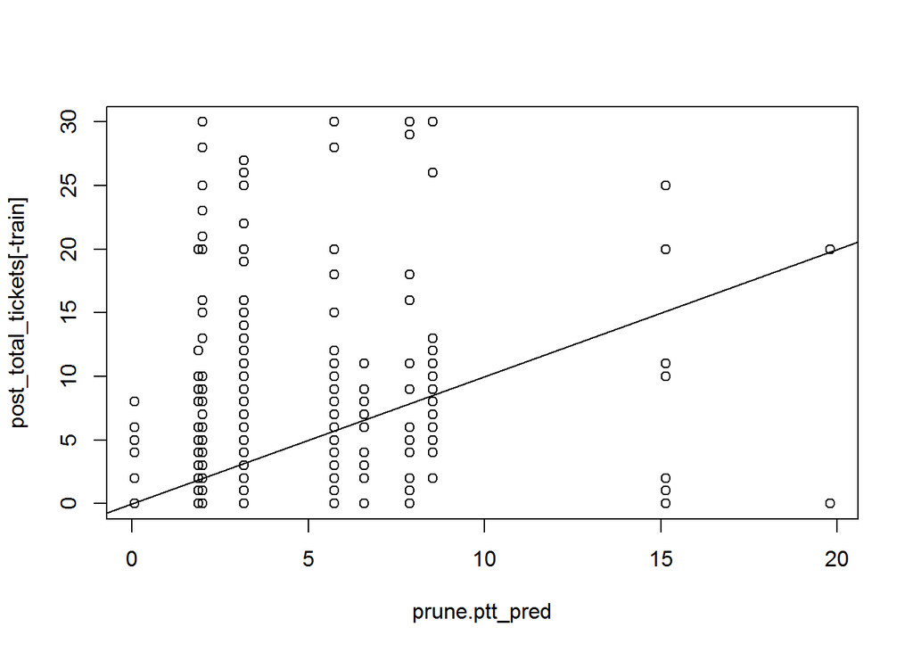

```r
#Fitting model on test set
prune.ptt_pred <- predict(prune.ptt_train, dataset.ptt[-train,])
plot(prune.ptt_pred, post_total_tickets[-train])
abline(0,1)
```

```r
#Mean Squared Error
MSE.prune.ptt <- mean((prune.ptt_pred-post_total_tickets[-train])^2)
MSE.prune.ptt
```

```
## [1] 11.83655
```

```r
A_methods <- rbind(A_methods, c('Cross Validated Tree',MSE.prune.ptt))
```

```
## [1] "Test MSE is 11.8365472502529 . Root MSE is 3.44042835272774 , indicating this model leads to test predictions within around 3.44 total tickets purchased."
```

Creating Bagged Tree

```r
#Creating a modified dataset - na values are not accepted in bagged trees
dataset.ptt0 <- dataset.ptt
dataset.ptt0[is.na(dataset.ptt0)] <- 0
```

```r
attach(dataset.ptt0)
```

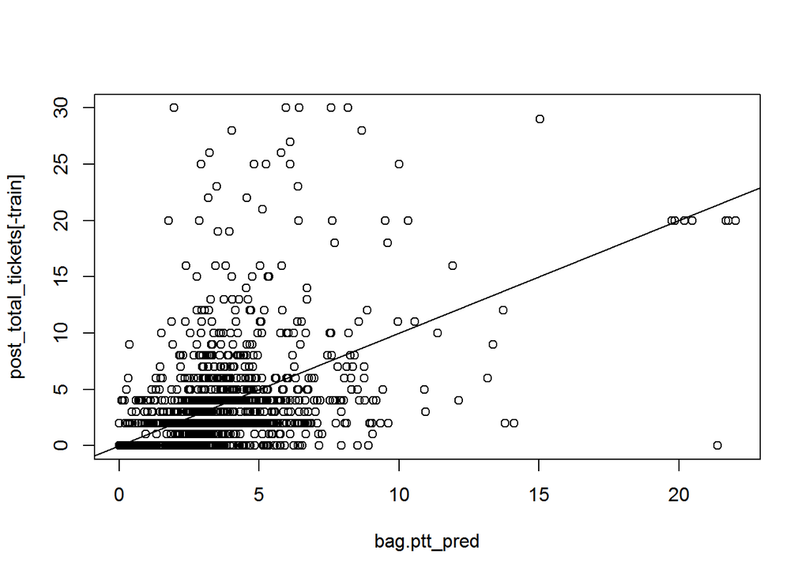

```r
#Growing Tree
bag.ptt_train <- randomForest(post_total_tickets~., data=dataset.ptt0, subset=train, mtry=ncol(dataset.ptt0)-1, ntrees=1000, importance=TRUE)
#Can't plot tree
#Fitting model on test set
bag.ptt_pred <- predict(bag.ptt_train, dataset.ptt0[-train,])
plot(bag.ptt_pred, post_total_tickets[-train])
abline(0,1)
```

```r
#Mean Squared Error
MSE.bag.ptt <- mean((bag.ptt_pred-post_total_tickets[-train])^2)
MSE.bag.ptt
```

```
## [1] 10.89291
```

```r
A_methods <- rbind(A_methods, c('Bagged Tree',MSE.bag.ptt))
```

```
## [1] "Test MSE is 10.8929140635512 . Root MSE is 3.30044149524744 , indicating this model leads to test predictions within around 3.3 total tickets purchased."
```

Looking at Predictor Importance

```r
bag.I <- importance(bag.ptf_train)
bag.I <- bag.I[ order(bag.I[,3],decreasing=TRUE), ]
```

[output not shown]

```r
bag.I[1:15,] #includes variable 'tenure' - is this to be removed from this dataset as well?
```

```
##                                  No         Yes MeanDecreaseAccuracy
## livea_match_cd             75.17985 143.7466618            102.08917
## multiple_emails            73.42160  61.7100075             90.40405
## individual_id_new          69.22972  20.5441986             76.47259
## fansource                  67.63132  34.5012216             74.14815
## pre_ticket_package_derived 54.43818  42.6228591             60.81960
## pre_total_ticket_amt_l24   15.89687  27.6934349             28.27767
## pre_tmc                    29.58063   9.0105793             28.03816
## zip_code                   13.24718  20.6819312             26.56142
## agecat                     25.57066   3.0907834             25.89703
## pre_total_ticket_amt_l36   20.59177  20.6704607             25.71584
## closest_arena_distance     16.41883  18.1777106             25.40917
## closeteam                  38.80255  -0.4406122             25.35390
## closest_team               35.72005   0.3578906             24.37412
## tenure                     38.01633 -12.2994680             24.09423
## Team                       38.91309  -0.4907687             23.98719
##                            MeanDecreaseGini
## livea_match_cd                   1543.29606
## multiple_emails                   123.74787
## individual_id_new                 290.74053
## fansource                         212.51842
## pre_ticket_package_derived        277.18122
## pre_total_ticket_amt_l24           89.19680
## pre_tmc                           109.52302
## zip_code                           91.68983
## agecat                             40.79445
## pre_total_ticket_amt_l36           67.63627
## closest_arena_distance            144.38831
## closeteam                         117.01979
## closest_team                      118.78998
## tenure                            147.57536
## Team                              116.08163
```

```r
bag.I <- bag.I[ order(bag.I[,4],decreasing=TRUE), ]
```

[output not shown]

```r
bag.I[1:15,] #includes variable 'tenure' - is this to be removed from this dataset as well?
```

```
##                                  No         Yes MeanDecreaseAccuracy
## livea_match_cd             75.17985 143.7466618            102.08917
## individual_id_new          69.22972  20.5441986             76.47259
## pre_ticket_package_derived 54.43818  42.6228591             60.81960
## fansource                  67.63132  34.5012216             74.14815
## tenure                     38.01633 -12.2994680             24.09423
## closest_arena_distance     16.41883  18.1777106             25.40917
## multiple_emails            73.42160  61.7100075             90.40405
## closest_team               35.72005   0.3578906             24.37412
## closeteam                  38.80255  -0.4406122             25.35390
## Team                       38.91309  -0.4907687             23.98719
## pre_tmc                    29.58063   9.0105793             28.03816
## zip_code                   13.24718  20.6819312             26.56142
## pre_total_ticket_amt_l24   15.89687  27.6934349             28.27767
## pre_total_ticket_amt_l36   20.59177  20.6704607             25.71584
## pre_total_tickets_l24      13.37717  20.1920414             20.50801
##                            MeanDecreaseGini
## livea_match_cd                   1543.29606
## individual_id_new                 290.74053
## pre_ticket_package_derived        277.18122
## fansource                         212.51842
## tenure                            147.57536
## closest_arena_distance            144.38831
## multiple_emails                   123.74787
## closest_team                      118.78998
## closeteam                         117.01979
## Team                              116.08163
## pre_tmc                           109.52302
## zip_code                           91.68983
## pre_total_ticket_amt_l24           89.19680
## pre_total_ticket_amt_l36           67.63627
## pre_total_tickets_l24              61.30746
```

Creating Random Forest Tree

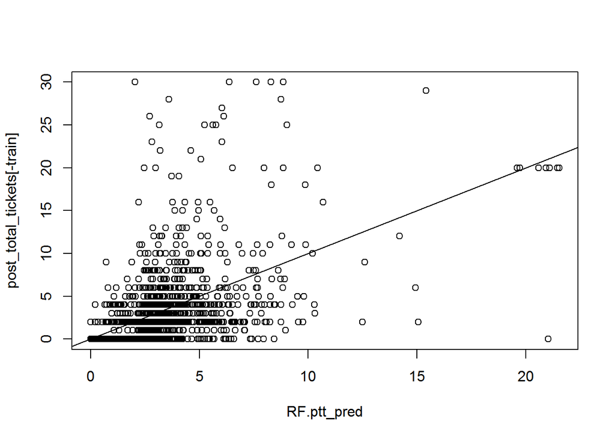

```r
#Growing Tree
RF.ptt_train <- randomForest(post_total_tickets~., data=dataset.ptt0, subset=train, importance=TRUE)
#Can't plot tree
#Fitting model on test set
RF.ptt_pred <- predict(RF.ptt_train, dataset.ptt0[-train,])
plot(RF.ptt_pred, post_total_tickets[-train])
abline(0,1)
```

```r
#Mean Squared Error
MSE.RF.ptt <- mean((RF.ptt_pred-post_total_tickets[-train])^2)
MSE.RF.ptt
```

```
## [1] 10.74016
```

```r
A_methods <- rbind(A_methods, c('Random Forest Tree',MSE.RF.ptt))
```

[output not shown]

Looking at Predictor Importance

```r
RF.I <- importance(RF.ptf_train)
RF.I <- RF.I[ order(RF.I[,3],decreasing=TRUE), ]
```

[output not shown]

```r
RF.I[1:15,] #includes variable 'tenure' - is this to be removed from this dataset as well?
```

```
##                                 No        Yes MeanDecreaseAccuracy
## livea_match_cd           42.228246  44.684126             47.07024
## multiple_emails          29.668165  38.167227             37.40318
## individual_id_new        26.691286  32.726671             31.19541
## closeteam                38.399946 -14.659979             25.62129
## closest_team             39.383577 -13.121204             25.19247
## fansource                19.783370  21.625172             24.44881
## Team                     36.439361 -14.119365             24.31604
## tenure                   23.774787  -6.706960             21.70614
## zip_code                 16.792508   9.570484             21.53381
## closest_arena_distance   15.820300  10.627551             19.77468
## pre_arc                  15.721207  19.152875             18.60875
## source4                  18.643692   7.981662             18.60662
## pre_tmc                  16.129192  11.105331             18.55371
## agecat                   15.932942   4.285244             16.38365
## pre_total_ticket_amt_l24  6.354642  20.841383             15.54312
##                          MeanDecreaseGini
## livea_match_cd                  477.02364
## multiple_emails                 144.49416
## individual_id_new               248.10846
## closeteam                       128.41604
## closest_team                    127.17611
## fansource                       284.86497
## Team                            124.41620
## tenure                          105.06359
## zip_code                         68.98795
## closest_arena_distance           78.57637
## pre_arc                         213.42472
## source4                         212.31078
## pre_tmc                          42.62491
## agecat                           50.10372
## pre_total_ticket_amt_l24         73.23426
```

```r
RF.I <- RF.I[ order(RF.I[,4],decreasing=TRUE), ]
```

[output not shown]

```r
RF.I[1:15,] #includes variable 'tenure' - is this to be removed from this dataset as well?
```

```
##                                 No        Yes MeanDecreaseAccuracy
## livea_match_cd           42.228246  44.684126             47.07024
## fansource                19.783370  21.625172             24.44881
## individual_id_new        26.691286  32.726671             31.19541
## pre_arc                  15.721207  19.152875             18.60875
## source4                  18.643692   7.981662             18.60662
## multiple_emails          29.668165  38.167227             37.40318
## pre_total_ticket_amt_l36  8.890193  17.794637             14.65141
## closeteam                38.399946 -14.659979             25.62129
## closest_team             39.383577 -13.121204             25.19247
## Team                     36.439361 -14.119365             24.31604
## pre_total_tickets_cat     8.855882   8.911857             10.23351
## pre_total_tickets         9.292206  12.446478             12.25065
## tenure                   23.774787  -6.706960             21.70614
## pre_total_tickets_l36     9.262595  11.872385             12.42088
## closest_arena_distance   15.820300  10.627551             19.77468
##                          MeanDecreaseGini
## livea_match_cd                  477.02364
## fansource                       284.86497
## individual_id_new               248.10846
## pre_arc                         213.42472
## source4                         212.31078
## multiple_emails                 144.49416
## pre_total_ticket_amt_l36        131.12625
## closeteam                       128.41604
## closest_team                    127.17611
## Team                            124.41620
## pre_total_tickets_cat           109.35496
## pre_total_tickets               105.77790
## tenure                          105.06359
## pre_total_tickets_l36            96.66739
## closest_arena_distance           78.57637
```

Creating a Boosted Tree

```r
#Creating a modified dataset - columns with no variation are not accepted in boosted trees
dataset.pttB <- dataset.ptt
colnames(dataset.pttB)[c(36,56)]
```

```
## [1] "ind_events_allstar_1y" "pre_pac"
```

```r
dataset.pttB <- dataset.pttB[,-c(36,56)]
```

```r
attach(dataset.pttB)
```

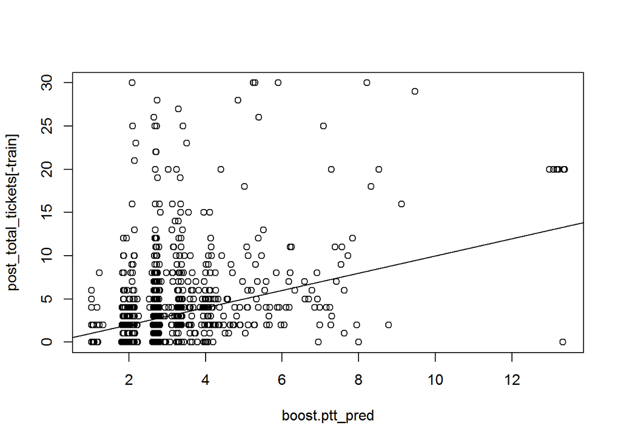

```r
#Growing Tree
boost.ptt_train <- gbm(post_total_tickets~., data=dataset.pttB[train,], distribution='gaussian', n.trees=1000, interaction.depth=4)
#Can't plot tree
#Fitting model on test set
boost.ptt_pred <- predict(boost.ptt_train, dataset.pttB[-train,], n.trees=1000)
plot(boost.ptt_pred, post_total_tickets[-train])
abline(0,1)
```

```r
#Mean Squared Error
MSE.boost.ptt <- mean((boost.ptt_pred-post_total_tickets[-train])^2)
MSE.boost.ptt
```

```
## [1] 11.93671
```

```r
A_methods <- rbind(A_methods, c('Boosted Tree',MSE.boost.ptt))
```

```
## [1] "Test MSE is 11.936708527275 . Root MSE is 3.45495420045983 , indicating this model leads to test predictions within around 3.45 total tickets purchased."
```

Looking at Most Effective Method

```r
A_methods <- A_methods[-1,]
A_methods[order(A_methods[,2],decreasing = FALSE),]
```

```
##      [,1]                   [,2]
## [1,] "Random Forest Tree"   "10.7401626883238"
## [2,] "Bagged Tree"          "10.8929140635512"
## [3,] "Tree"                 "11.8365472502529"
## [4,] "Cross Validated Tree" "11.8365472502529"
## [5,] "Boosted Tree"         "11.936708527275"
```

```r
Top <- A_methods[1,]
```

[output not shown]

Back to top

### C - How much money do people spend on tickets?

Removing other response variables besides post_total_ticket_amt

```r
Q <- match('post_total_ticket_amt',a)
a[Q]
```

```
## [1] "post_total_ticket_amt"
```

```r
POSTN_ptta <- POSTN[! POSTN %in% Q]
#POSTN_ptta
a[POSTN_ptta]
```

```
##  [1] "post_ticket_response"        "post_tickets_flag"
##  [3] "post_total_tickets"          "post_avg_ticket_price"
##  [5] "post_regular_season_tix"     "post_playoffs_tix"
##  [7] "post_arc_flag"               "post_tmc_flag"
##  [9] "post_tmc_resale_flag"        "post_vtx_flag"
## [11] "post_vtx_flash_flag"         "post_ticket_package_arc"
## [13] "post_ticket_package_derived" "post_total_tickets_cat"
```

```r
dataset.ptta <- d[,-POSTN_ptta]
```

```r
attach(dataset.ptta)
```

Looking at distribution of test responst variable

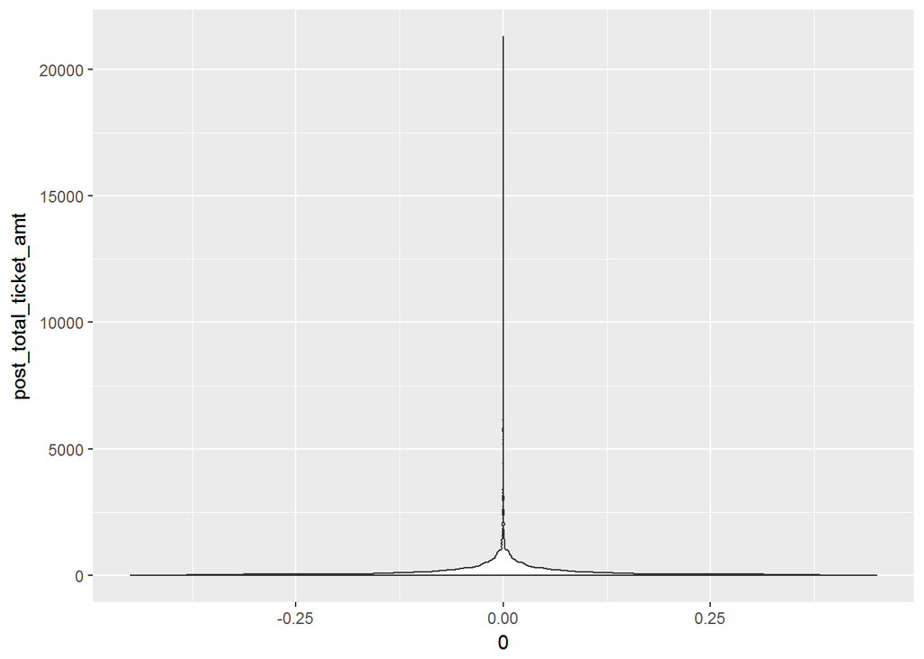

```r
#Creating Violin Plot
p <- ggplot(dataset.ptta[-train,], aes(y=post_total_ticket_amt, 0))
p + geom_violin()
```

```r
#Finding Number of Zeroes
O <- table(post_total_ticket_amt[-train]==0)
#O[2]
```

```
## [1] "0.497 of the values are zeroes."
```

**Growing Trees**

Growing Preliminary Regression Tree

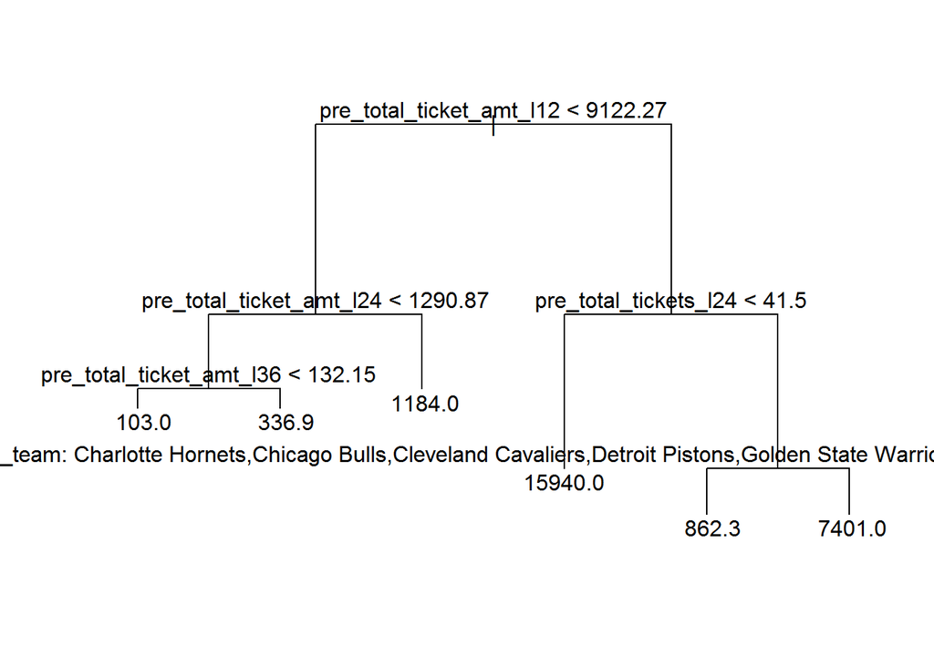

```r
tree.ptta <- tree(post_total_ticket_amt~., dataset.ptta)
plot(tree.ptta)
text(tree.ptta,pretty=0)
```

Estimate MSE on (extremely similar) Trained Tree

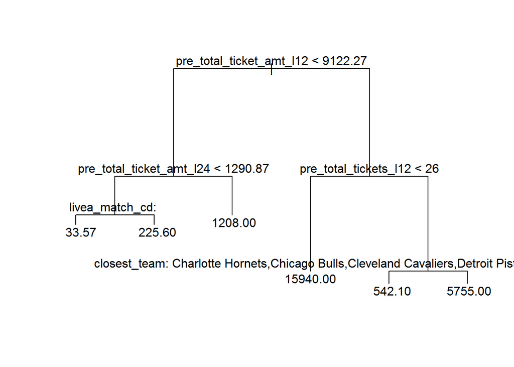

```r
#Growing Tree
tree.ptta_train <- tree(post_total_ticket_amt~., dataset.ptta, subset=train)
#Plotting Tree
plot(tree.ptta_train)
text(tree.ptta_train,pretty=0)
```

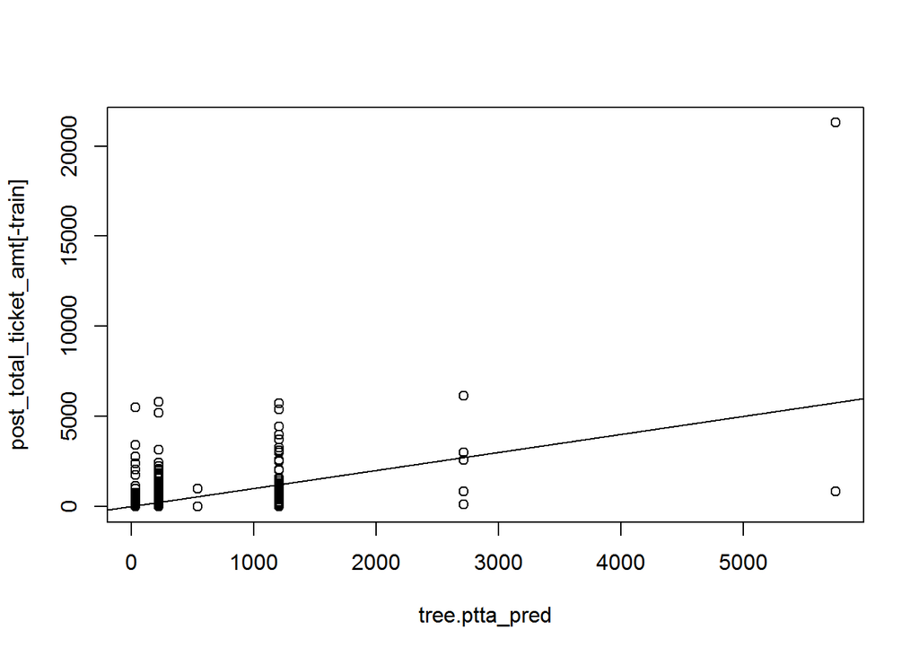

```r
#Fitting model on test set
tree.ptta_pred <- predict(tree.ptta_train, dataset.ptta[-train,])
plot(tree.ptta_pred, post_total_ticket_amt[-train])
abline(0,1)
```

```r
#Mean Squared Error
MSE.ptta <- mean((tree.ptta_pred-post_total_ticket_amt[-train])^2)
MSE.ptta
```

```
## [1] 309426.3
```

```r
A_methods <- rbind(A_methods, c("Tree",MSE.ptta))
```

```
## [1] "Test MSE is 309426.332798279 . Root MSE is 556.261029372254 , indicating this model leads to test predictions within around 556.3 dollars of total ticket amount."
```

Pruning the Tree

```r
#Cross Validating Tree
cv.ptta_train <- cv.tree(tree.ptta_train, FUN=prune.tree)
#Finding best parameter to prune
cv.ptta_train
```

```
## $size
## [1] 6 5 4 3 2 1
##
## $dev
## [1] 3331028971 3389256036 3413168345 3614311619 3866372935 3729662963
##
## $k
## [1]      -Inf  61612450  79246324 251163009 617420832 698965399
##
## $method
## [1] "deviance"
##
## attr(,"class")
## [1] "prune"         "tree.sequence"
```

```r
b <- which.min(cv.ptta_train$dev)
Best <- cv.ptta_train$size[b]
```

```
## [1] "The best trees seem to be of size 6 with deviation of 3331028971.33953 ."
```

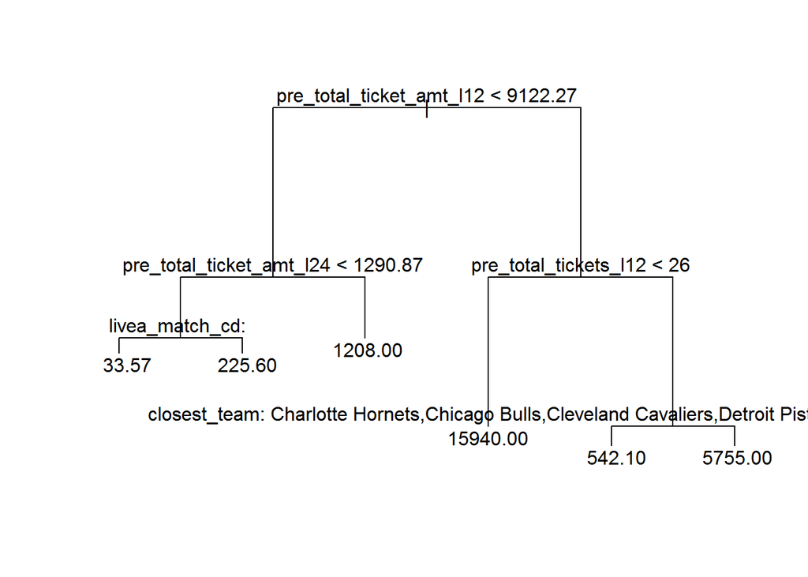

```r
#Pruning Tree based on this
prune.ptta_train <- prune.tree(tree.ptta_train, best=Best)
#Plotting Tree
plot(prune.ptta_train)
text(prune.ptta_train,pretty=0)
```

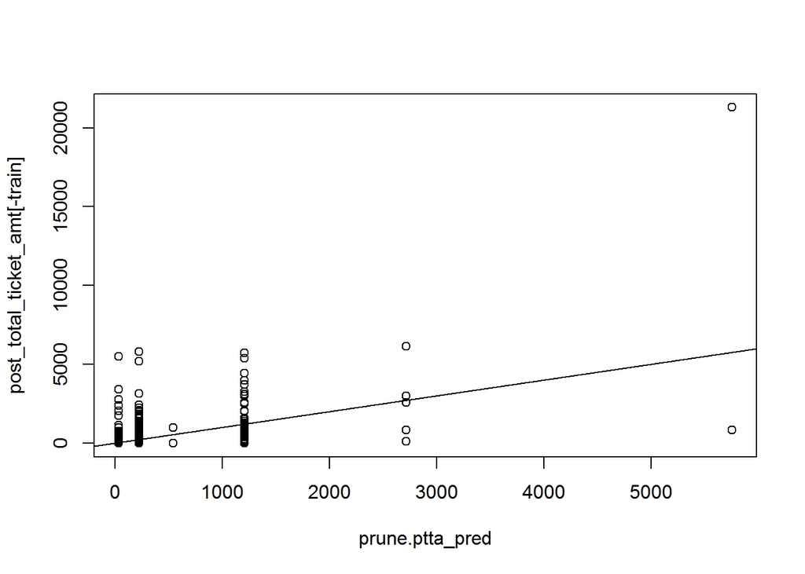

```r
#Fitting model on test set
prune.ptta_pred <- predict(prune.ptta_train, dataset.ptta[-train,])
plot(prune.ptta_pred, post_total_ticket_amt[-train])
abline(0,1)
```

```r
#Mean Squared Error
MSE.prune.ptta <- mean((prune.ptta_pred-post_total_ticket_amt[-train])^2)
MSE.prune.ptta
```

```
## [1] 309426.3
```

```r
A_methods <- rbind(A_methods, c("Cross Validated Tree",MSE.prune.ptta))
```

```
## [1] "Test MSE is 309426.332798279 . Root MSE is 556.261029372254 , indicating this model leads to test predictions within around 556.3 dollars of total ticket amount."
```

Creating Bagged Tree

```r
#Creating a modified dataset - na values are not accepted in bagged trees
dataset.ptta0 <- dataset.ptta
dataset.ptta0[is.na(dataset.ptta0)] <- 0
```

```r
attach(dataset.ptta0)
```

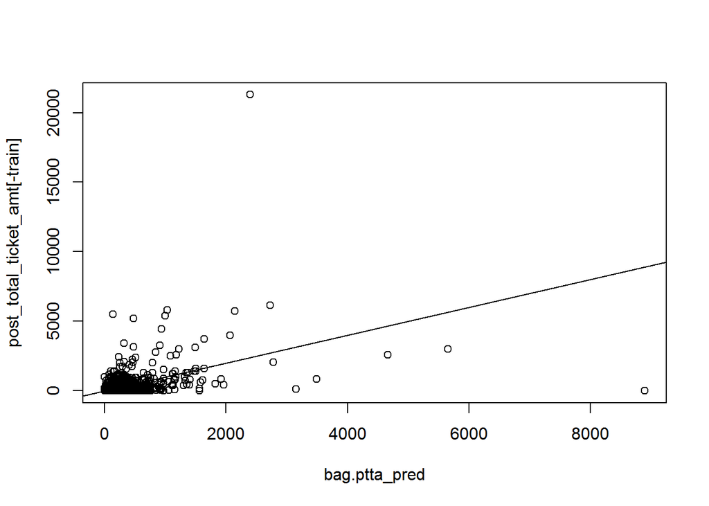

```r
#Growing Tree
bag.ptta_train <- randomForest(post_total_ticket_amt~., data=dataset.ptta0, subset=train, mtry=ncol(dataset.ptta0)-1, ntrees=1000, importance=TRUE)
#Can't plot tree
#Fitting model on test set
bag.ptta_pred <- predict(bag.ptta_train, dataset.ptta0[-train,])
plot(bag.ptta_pred, post_total_ticket_amt[-train])
abline(0,1)
```

```r
#Mean Squared Error
MSE.bag.ptta <- mean((bag.ptta_pred-post_total_ticket_amt[-train])^2)
MSE.bag.ptta
```

```
## [1] 386375.4
```

```r
A_methods <- rbind(A_methods, c("Bagged Tree",MSE.bag.ptta))
```

```
## [1] "Test MSE is 386375.35465029 . Root MSE is 621.590986622466 , indicating this model leads to test predictions within around 621.6 dollars of total ticket amount."
```

Looking at Predictor Importance

```r
bag.I <- importance(bag.ptf_train)
bag.I <- bag.I[ order(bag.I[,3],decreasing=TRUE), ]
```

```
## [1] "The fifteen most important predictors (by error) according to this model are as follows:"
```

```r
bag.I[1:15,] #includes variable 'tenure' - is this to be removed from this dataset as well?
```

```
##                                  No         Yes MeanDecreaseAccuracy
## livea_match_cd             75.17985 143.7466618            102.08917
## multiple_emails            73.42160  61.7100075             90.40405
## individual_id_new          69.22972  20.5441986             76.47259
## fansource                  67.63132  34.5012216             74.14815
## pre_ticket_package_derived 54.43818  42.6228591             60.81960
## pre_total_ticket_amt_l24   15.89687  27.6934349             28.27767
## pre_tmc                    29.58063   9.0105793             28.03816
## zip_code                   13.24718  20.6819312             26.56142
## agecat                     25.57066   3.0907834             25.89703
## pre_total_ticket_amt_l36   20.59177  20.6704607             25.71584
## closest_arena_distance     16.41883  18.1777106             25.40917
## closeteam                  38.80255  -0.4406122             25.35390
## closest_team               35.72005   0.3578906             24.37412
## tenure                     38.01633 -12.2994680             24.09423
## Team                       38.91309  -0.4907687             23.98719
##                            MeanDecreaseGini
## livea_match_cd                   1543.29606
## multiple_emails                   123.74787
## individual_id_new                 290.74053
## fansource                         212.51842
## pre_ticket_package_derived        277.18122
## pre_total_ticket_amt_l24           89.19680
## pre_tmc                           109.52302
## zip_code                           91.68983
## agecat                             40.79445
## pre_total_ticket_amt_l36           67.63627
## closest_arena_distance            144.38831
## closeteam                         117.01979
## closest_team                      118.78998
## tenure                            147.57536
## Team                              116.08163
```

```r
bag.I <- bag.I[ order(bag.I[,4],decreasing=TRUE), ]
```

```
## [1] "The fifteen most important predictors (by Gini index) according to this model are as follows:"
```

```r
bag.I[1:15,] #includes variable 'tenure' - is this to be removed from this dataset as well?
```

```
##                                  No         Yes MeanDecreaseAccuracy
## livea_match_cd             75.17985 143.7466618            102.08917
## individual_id_new          69.22972  20.5441986             76.47259
## pre_ticket_package_derived 54.43818  42.6228591             60.81960
## fansource                  67.63132  34.5012216             74.14815
## tenure                     38.01633 -12.2994680             24.09423
## closest_arena_distance     16.41883  18.1777106             25.40917
## multiple_emails            73.42160  61.7100075             90.40405
## closest_team               35.72005   0.3578906             24.37412
## closeteam                  38.80255  -0.4406122             25.35390
## Team                       38.91309  -0.4907687             23.98719
## pre_tmc                    29.58063   9.0105793             28.03816
## zip_code                   13.24718  20.6819312             26.56142
## pre_total_ticket_amt_l24   15.89687  27.6934349             28.27767
## pre_total_ticket_amt_l36   20.59177  20.6704607             25.71584
## pre_total_tickets_l24      13.37717  20.1920414             20.50801
##                            MeanDecreaseGini
## livea_match_cd                   1543.29606
## individual_id_new                 290.74053
## pre_ticket_package_derived        277.18122
## fansource                         212.51842
## tenure                            147.57536
## closest_arena_distance            144.38831
## multiple_emails                   123.74787
## closest_team                      118.78998
## closeteam                         117.01979
## Team                              116.08163
## pre_tmc                           109.52302
## zip_code                           91.68983
## pre_total_ticket_amt_l24           89.19680
## pre_total_ticket_amt_l36           67.63627
## pre_total_tickets_l24              61.30746
```

Creating Random Forest Tree

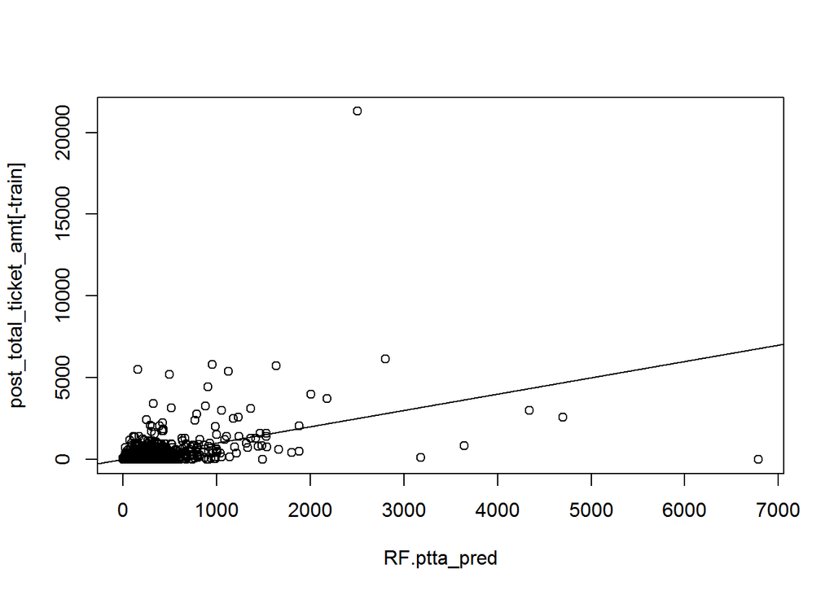

```r
#Growing Tree
RF.ptta_train <- randomForest(post_total_ticket_amt~., data=dataset.ptta0, subset=train, importance=TRUE)
#Can't plot tree
#Fitting model on test set
RF.ptta_pred <- predict(RF.ptta_train, dataset.ptta0[-train,])
plot(RF.ptta_pred, post_total_ticket_amt[-train])
abline(0,1)
```

```r
#Mean Squared Error
MSE.RF.ptta <- mean((RF.ptta_pred-post_total_ticket_amt[-train])^2)
MSE.RF.ptta
```

```
## [1] 361782.5
```

```r
A_methods <- rbind(A_methods, c("Random Forest Tree",MSE.RF.ptta))
```

[output not shown]

Looking at Predictor Importance

```r
RF.I <- importance(RF.ptf_train)
RF.I <- RF.I[ order(RF.I[,3],decreasing=TRUE), ]
```

```
## [1] "The fifteen most important predictors (by error) according to this model are as follows:"
```

```r
RF.I[1:15,] #includes variable 'tenure' - is this to be removed from this dataset as well?
```

```
##                                 No        Yes MeanDecreaseAccuracy
## livea_match_cd           42.228246  44.684126             47.07024
## multiple_emails          29.668165  38.167227             37.40318
## individual_id_new        26.691286  32.726671             31.19541
## closeteam                38.399946 -14.659979             25.62129
## closest_team             39.383577 -13.121204             25.19247
## fansource                19.783370  21.625172             24.44881
## Team                     36.439361 -14.119365             24.31604
## tenure                   23.774787  -6.706960             21.70614
## zip_code                 16.792508   9.570484             21.53381
## closest_arena_distance   15.820300  10.627551             19.77468
## pre_arc                  15.721207  19.152875             18.60875
## source4                  18.643692   7.981662             18.60662
## pre_tmc                  16.129192  11.105331             18.55371
## agecat                   15.932942   4.285244             16.38365
## pre_total_ticket_amt_l24  6.354642  20.841383             15.54312
##                          MeanDecreaseGini
## livea_match_cd                  477.02364
## multiple_emails                 144.49416
## individual_id_new               248.10846
## closeteam                       128.41604
## closest_team                    127.17611
## fansource                       284.86497
## Team                            124.41620
## tenure                          105.06359
## zip_code                         68.98795
## closest_arena_distance           78.57637
## pre_arc                         213.42472
## source4                         212.31078
## pre_tmc                          42.62491
## agecat                           50.10372
## pre_total_ticket_amt_l24         73.23426
```

```r
RF.I <- RF.I[ order(RF.I[,4],decreasing=TRUE), ]
```

```
## [1] "The fifteen most important predictors (by Gini index) according to this model are as follows:"
```

```r
RF.I[1:15,] #includes variable 'tenure' - is this to be removed from this dataset as well?
```

```
##                                 No        Yes MeanDecreaseAccuracy
## livea_match_cd           42.228246  44.684126             47.07024
## fansource                19.783370  21.625172             24.44881
## individual_id_new        26.691286  32.726671             31.19541
## pre_arc                  15.721207  19.152875             18.60875
## source4                  18.643692   7.981662             18.60662
## multiple_emails          29.668165  38.167227             37.40318
## pre_total_ticket_amt_l36  8.890193  17.794637             14.65141
## closeteam                38.399946 -14.659979             25.62129
## closest_team             39.383577 -13.121204             25.19247
## Team                     36.439361 -14.119365             24.31604
## pre_total_tickets_cat     8.855882   8.911857             10.23351
## pre_total_tickets         9.292206  12.446478             12.25065
## tenure                   23.774787  -6.706960             21.70614
## pre_total_tickets_l36     9.262595  11.872385             12.42088
## closest_arena_distance   15.820300  10.627551             19.77468
##                          MeanDecreaseGini
## livea_match_cd                  477.02364
## fansource                       284.86497
## individual_id_new               248.10846
## pre_arc                         213.42472
## source4                         212.31078
## multiple_emails                 144.49416
## pre_total_ticket_amt_l36        131.12625
## closeteam                       128.41604
## closest_team                    127.17611
## Team                            124.41620
## pre_total_tickets_cat           109.35496
## pre_total_tickets               105.77790
## tenure                          105.06359
## pre_total_tickets_l36            96.66739
## closest_arena_distance           78.57637
```

Creating a Boosted Tree

```r
#Creating a modified dataset - columns with no variation are not accepted in boosted trees
dataset.pttaB <- dataset.ptta
colnames(dataset.pttaB)[c(36,56)]
```

```
## [1] "ind_events_allstar_1y" "pre_pac"
```

```r
dataset.pttaB <- dataset.pttaB[,-c(36,56)]
```

```r
attach(dataset.pttaB)
```

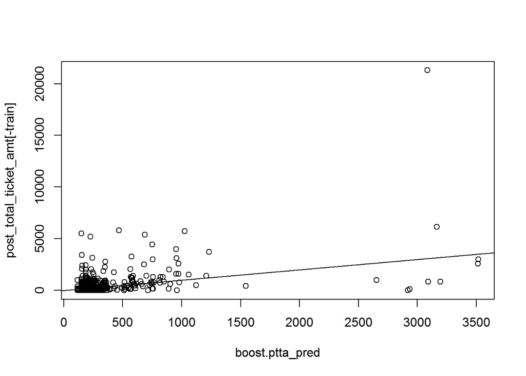

```r
#Growing Tree
boost.ptta_train <- gbm(post_total_ticket_amt~., data=dataset.pttaB[train,], distribution='gaussian', n.trees=1000, interaction.depth=4)
#Can't plot tree
#Fitting model on test set
boost.ptta_pred <- predict(boost.ptta_train, dataset.pttaB[-train,], n.trees=1000)
plot(boost.ptta_pred, post_total_ticket_amt[-train])
abline(0,1)
```

```r
#Mean Squared Error
MSE.boost.ptta <- mean((boost.ptta_pred-post_total_ticket_amt[-train])^2)
MSE.boost.ptta
```

```
## [1] 348982.2
```

```r
A_methods <- rbind(A_methods, c("Boosted Tree",MSE.boost.ptta))
```

```
## [1] "Test MSE is 348982.197915014 . Root MSE is 590.747152269915 , indicating this model leads to test predictions within around 590.7 dollars of total ticket amount."
```

Looking at Most Effective Method

```r
A_methods <- A_methods[-1,]
A_methods[order(A_methods[,2],decreasing = FALSE),]
```

```
##      [,1]                   [,2]
## [1,] "Tree"                 "309426.332798279"
## [2,] "Cross Validated Tree" "309426.332798279"
## [3,] "Boosted Tree"         "348982.197915014"
## [4,] "Random Forest Tree"   "361782.453131236"
## [5,] "Bagged Tree"          "386375.35465029"
```

```r
Top <- A_methods[1,]
```

```
## [1] "The most effective method was the Tree , with 309426.332798279 MSE."
```

Back to top

### D - Who buys tickets at which price?

Removing other response variables besides post_avg_ticket_price

```r
Q <- match('post_avg_ticket_price',a)
a[Q]
```

```
## [1] "post_avg_ticket_price"
```

```r
POSTN_patp <- POSTN[! POSTN %in% Q]
#POSTN_patp
a[POSTN_patp]
```

```
##  [1] "post_ticket_response"        "post_tickets_flag"
##  [3] "post_total_ticket_amt"       "post_total_tickets"
##  [5] "post_regular_season_tix"     "post_playoffs_tix"
##  [7] "post_arc_flag"               "post_tmc_flag"
##  [9] "post_tmc_resale_flag"        "post_vtx_flag"
## [11] "post_vtx_flash_flag"         "post_ticket_package_arc"
## [13] "post_ticket_package_derived" "post_total_tickets_cat"
```

```r
dataset.patp <- d[,-POSTN_patp]
```

```r
attach(dataset.patp)
```

Looking at distribution of test response variable

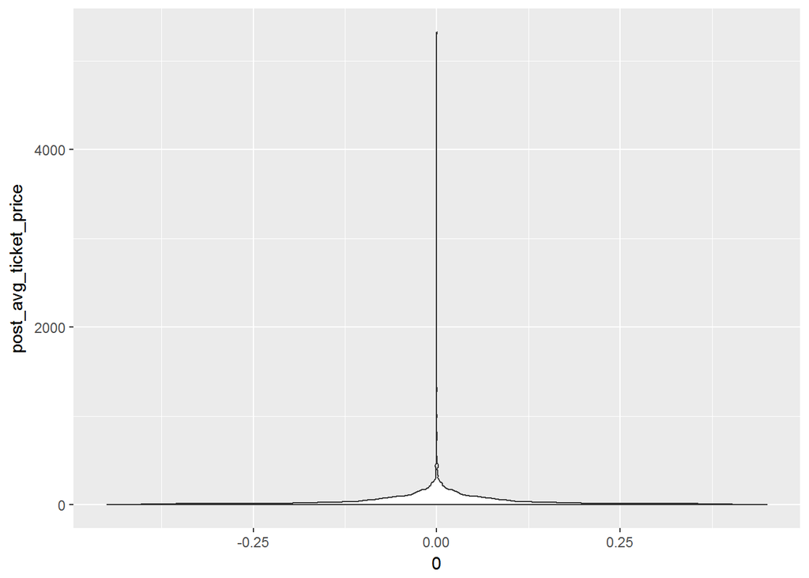

```r
#Creating Violin Plot
p <- ggplot(dataset.patp[-train,], aes(y=post_avg_ticket_price, 0))
p + geom_violin()
```

```r
#Finding Number of Zeroes
O <- table(post_avg_ticket_price[-train]==0)
#O[2]
```

```
## [1] "0.497 of the values are zeroes."
```

**Growing Trees**

Growing Preliminary Regression Tree

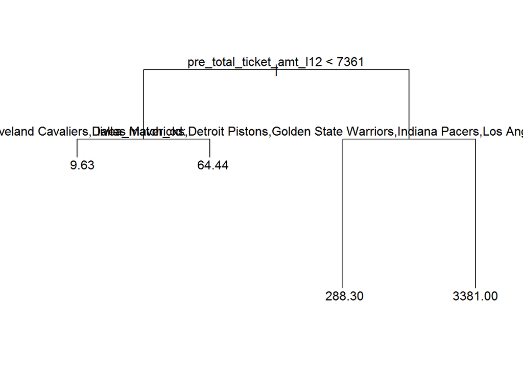

```r
tree.patp <- tree(post_avg_ticket_price~., dataset.patp)
plot(tree.patp)
text(tree.patp,pretty=0)
```

Estimate MSE on (extremely similar) Trained Tree

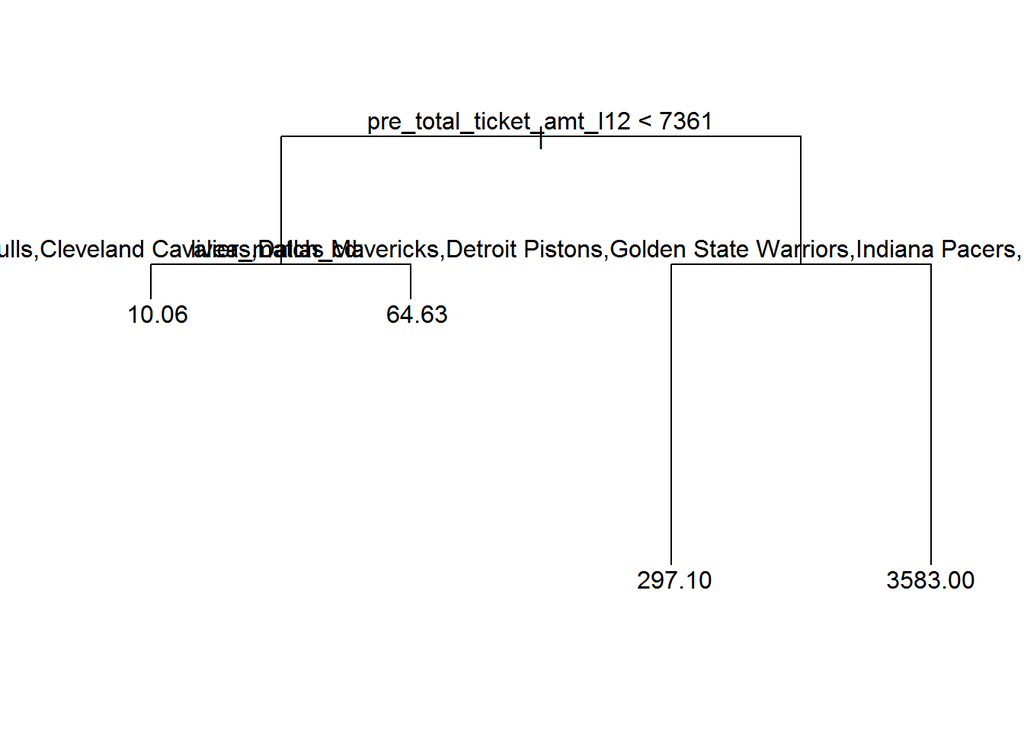

```r
#Growing Tree
tree.patp_train <- tree(post_avg_ticket_price~., dataset.patp, subset=train)
#Plotting Tree
plot(tree.patp_train)
text(tree.patp_train,pretty=0)
```

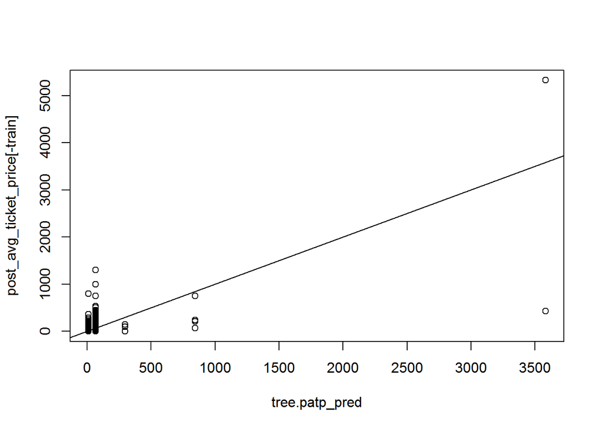

```r
#Fitting model on test set
tree.patp_pred <- predict(tree.patp_train, dataset.patp[-train,])
plot(tree.patp_pred, post_avg_ticket_price[-train])
abline(0,1)
```

```r
#Mean Squared Error
MSE.patp <- mean((tree.patp_pred-post_avg_ticket_price[-train])^2)
MSE.patp
```

```
## [1] 12644.43
```

```r
A_methods <- rbind(A_methods, c("Tree",MSE.patp ))
```

```
## [1] "Test MSE is 12644.4269476081 . Root MSE is 112.447440822849 , indicating this model leads to test predictions within around 112.4 dollars of the average ticket price."
```

Pruning the Tree

```r
#Cross Validating Tree
cv.patp_train <- cv.tree(tree.patp_train, FUN=prune.tree)
#Finding best parameter to prune tree
cv.patp_train
```

```
## $size
## [1] 4 3 1
##
## $dev
## [1] 191151188 196133472 214220975
##
## $k
## [1]     -Inf  5107469 32079938
##
## $method
## [1] "deviance"
##
## attr(,"class")
## [1] "prune"         "tree.sequence"
```

```r
b <- which.min(cv.patp_train$dev)
Best <- cv.patp_train$size[b]
```

```
## [1] "The best trees seem to be of size 4 with deviation of 191151188.200144 ."
```

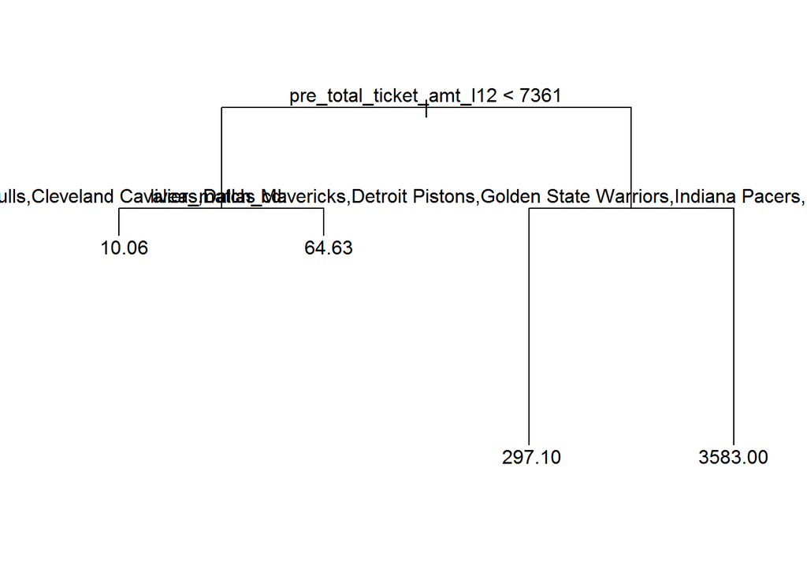

```r
#Pruning Tree based on this
prune.patp_train <- prune.tree(tree.patp_train, best=Best)
#Plotting Tree
plot(prune.patp_train)
text(prune.patp_train,pretty=0)
```

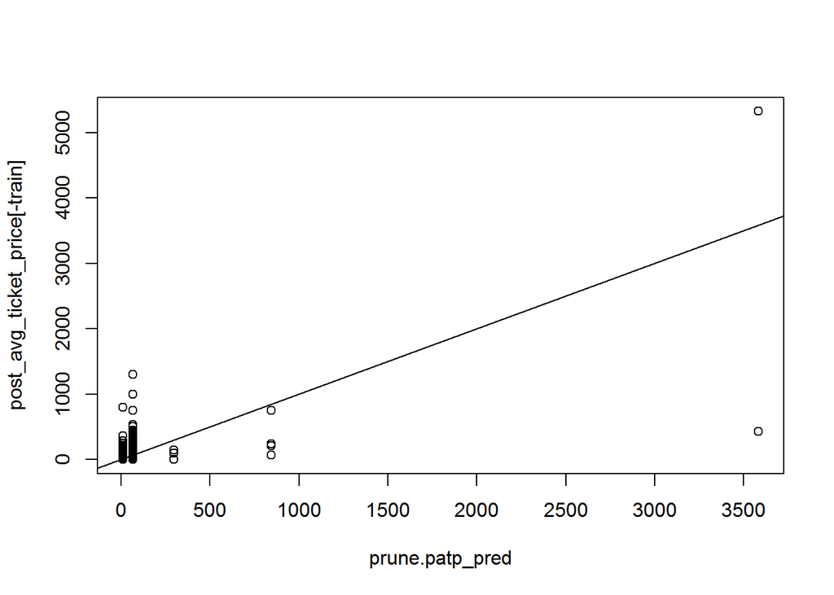

```r
#Fitting model on test set
prune.patp_pred <- predict(prune.patp_train, dataset.patp[-train,])
plot(prune.patp_pred, post_avg_ticket_price[-train])
abline(0,1)
```

```r
#Mean Squared Error
MSE.prune.patp <- mean((prune.patp_pred-post_avg_ticket_price[-train])^2)
MSE.prune.patp
```

```
## [1] 12644.43
```

```r
A_methods <- rbind(A_methods, c("Cross Validated Tree",MSE.prune.patp))
```

```
## [1] "Test MSE is 12644.4269476081 . Root MSE is 112.447440822849 , indicating this model leads to test predictions within around 112.4 dollars of the average ticket price."
```

Creating Bagged Tree

```r
#Creating a modified dataset - na values are not accepted in bagged trees
dataset.patp0 <- dataset.patp
dataset.patp0[is.na(dataset.patp0)] <- 0
```

```r
attach(dataset.patp0)
```

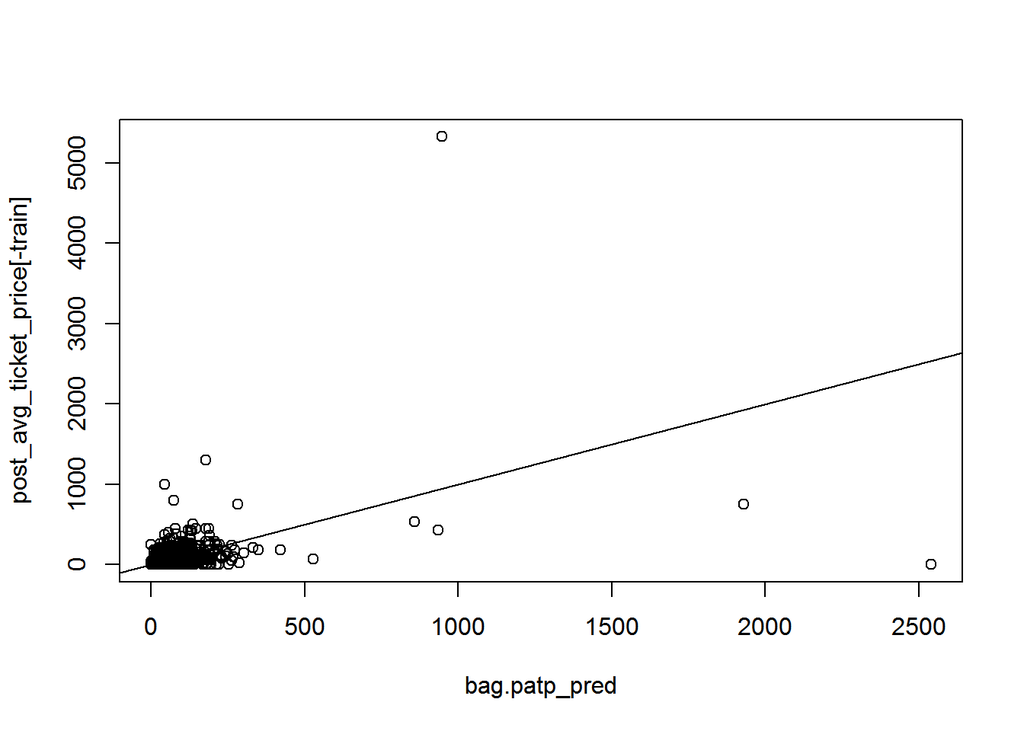

```r
#Growing Tree
bag.patp_train <- randomForest(post_avg_ticket_price~., data=dataset.patp0, subset=train, mtry=ncol(dataset.patp0)-1, ntrees=1000, importance=TRUE)
#Can't plot tree
#Fitting model on test set
bag.patp_pred <- predict(bag.patp_train, dataset.patp0[-train,])
plot(bag.patp_pred, post_avg_ticket_price[-train])
abline(0,1)
```

```r
#Mean Squared Error
MSE.bag.patp <- mean((bag.patp_pred-post_avg_ticket_price[-train])^2)
MSE.bag.patp
```

```
## [1] 18201.4
```

```r
A_methods <- rbind(A_methods, c("Bagged Tree",MSE.bag.patp))
```

```
## [1] "Test MSE is 18201.3976704181 . Root MSE is 134.912555644084 , indicating this model leads to test predictions within around 134.9 dollars of the average ticket price."
```

Looking at Predictor Importance

```r
bag.I <- importance(bag.ptf_train)
bag.I <- bag.I[ order(bag.I[,3],decreasing=TRUE), ]
```

```
## [1] "The fifteen most important predictors (by error) according to this model are as follows:"
```

```r
bag.I[1:15,] #includes variable 'tenure' - is this to be removed from this dataset as well?
```

```
##                                  No         Yes MeanDecreaseAccuracy
## livea_match_cd             75.17985 143.7466618            102.08917
## multiple_emails            73.42160  61.7100075             90.40405
## individual_id_new          69.22972  20.5441986             76.47259
## fansource                  67.63132  34.5012216             74.14815
## pre_ticket_package_derived 54.43818  42.6228591             60.81960
## pre_total_ticket_amt_l24   15.89687  27.6934349             28.27767
## pre_tmc                    29.58063   9.0105793             28.03816
## zip_code                   13.24718  20.6819312             26.56142
## agecat                     25.57066   3.0907834             25.89703
## pre_total_ticket_amt_l36   20.59177  20.6704607             25.71584
## closest_arena_distance     16.41883  18.1777106             25.40917
## closeteam                  38.80255  -0.4406122             25.35390
## closest_team               35.72005   0.3578906             24.37412
## tenure                     38.01633 -12.2994680             24.09423
## Team                       38.91309  -0.4907687             23.98719
##                            MeanDecreaseGini
## livea_match_cd                   1543.29606
## multiple_emails                   123.74787
## individual_id_new                 290.74053
## fansource                         212.51842
## pre_ticket_package_derived        277.18122
## pre_total_ticket_amt_l24           89.19680
## pre_tmc                           109.52302
## zip_code                           91.68983
## agecat                             40.79445
## pre_total_ticket_amt_l36           67.63627
## closest_arena_distance            144.38831
## closeteam                         117.01979
## closest_team                      118.78998
## tenure                            147.57536
## Team                              116.08163
```

```r
bag.I <- bag.I[ order(bag.I[,4],decreasing=TRUE), ]
```

```
## [1] "The fifteen most important predictors (by Gini index) according to this model are as follows:"
```

```r
bag.I[1:15,] #includes variable 'tenure' - is this to be removed from this dataset as well?
```

```
##                                  No         Yes MeanDecreaseAccuracy
## livea_match_cd             75.17985 143.7466618            102.08917
## individual_id_new          69.22972  20.5441986             76.47259
## pre_ticket_package_derived 54.43818  42.6228591             60.81960
## fansource                  67.63132  34.5012216             74.14815
## tenure                     38.01633 -12.2994680             24.09423
## closest_arena_distance     16.41883  18.1777106             25.40917
## multiple_emails            73.42160  61.7100075             90.40405
## closest_team               35.72005   0.3578906             24.37412
## closeteam                  38.80255  -0.4406122             25.35390
## Team                       38.91309  -0.4907687             23.98719
## pre_tmc                    29.58063   9.0105793             28.03816
## zip_code                   13.24718  20.6819312             26.56142
## pre_total_ticket_amt_l24   15.89687  27.6934349             28.27767
## pre_total_ticket_amt_l36   20.59177  20.6704607             25.71584
## pre_total_tickets_l24      13.37717  20.1920414             20.50801
##                            MeanDecreaseGini
## livea_match_cd                   1543.29606
## individual_id_new                 290.74053
## pre_ticket_package_derived        277.18122
## fansource                         212.51842
## tenure                            147.57536
## closest_arena_distance            144.38831
## multiple_emails                   123.74787
## closest_team                      118.78998
## closeteam                         117.01979
## Team                              116.08163
## pre_tmc                           109.52302
## zip_code                           91.68983
## pre_total_ticket_amt_l24           89.19680
## pre_total_ticket_amt_l36           67.63627
## pre_total_tickets_l24              61.30746
```

Creating Random Forest Tree

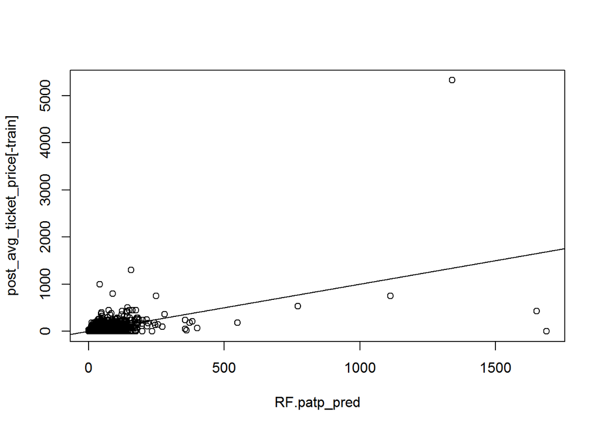

```r
#Growing Tree
RF.patp_train <- randomForest(post_avg_ticket_price~., data=dataset.patp0, subset=train, importance=TRUE)
#Can't plot tree
#Fitting model on test set
RF.patp_pred <- predict(RF.patp_train, dataset.patp0[-train,])
plot(RF.patp_pred, post_avg_ticket_price[-train])
abline(0,1)
```

```r
#Mean Squared Error
MSE.RF.patp <- mean((RF.patp_pred-post_avg_ticket_price[-train])^2)
MSE.RF.patp
```

```
## [1] 14651.7
```

```r
A_methods <- rbind(A_methods, c("Random Forest Tree",MSE.RF.patp))
```

[output not shown]

Looking at Predictor Importance

```r
RF.I <- importance(RF.ptf_train)
RF.I <- RF.I[ order(RF.I[,3],decreasing=TRUE), ]
```

```
## [1] "The fifteen most important predictors (by error) according to this model are as follows:"
```

```r
RF.I[1:15,] #includes variable 'tenure' - is this to be removed from this dataset as well?
```

```
##                                 No        Yes MeanDecreaseAccuracy
## livea_match_cd           42.228246  44.684126             47.07024
## multiple_emails          29.668165  38.167227             37.40318
## individual_id_new        26.691286  32.726671             31.19541
## closeteam                38.399946 -14.659979             25.62129
## closest_team             39.383577 -13.121204             25.19247
## fansource                19.783370  21.625172             24.44881
## Team                     36.439361 -14.119365             24.31604
## tenure                   23.774787  -6.706960             21.70614
## zip_code                 16.792508   9.570484             21.53381
## closest_arena_distance   15.820300  10.627551             19.77468
## pre_arc                  15.721207  19.152875             18.60875
## source4                  18.643692   7.981662             18.60662
## pre_tmc                  16.129192  11.105331             18.55371
## agecat                   15.932942   4.285244             16.38365
## pre_total_ticket_amt_l24  6.354642  20.841383             15.54312
##                          MeanDecreaseGini
## livea_match_cd                  477.02364
## multiple_emails                 144.49416
## individual_id_new               248.10846
## closeteam                       128.41604
## closest_team                    127.17611
## fansource                       284.86497
## Team                            124.41620
## tenure                          105.06359
## zip_code                         68.98795
## closest_arena_distance           78.57637
## pre_arc                         213.42472
## source4                         212.31078
## pre_tmc                          42.62491
## agecat                           50.10372
## pre_total_ticket_amt_l24         73.23426
```

```r
RF.I <- RF.I[ order(RF.I[,4],decreasing=TRUE), ]
```

```
## [1] "The fifteen most important predictors (by Gini index) according to this model are as follows:"
```

```r
RF.I[1:15,] #includes variable 'tenure' - is this to be removed from this dataset as well?
```

```
##                                 No        Yes MeanDecreaseAccuracy
## livea_match_cd           42.228246  44.684126             47.07024
## fansource                19.783370  21.625172             24.44881
## individual_id_new        26.691286  32.726671             31.19541
## pre_arc                  15.721207  19.152875             18.60875
## source4                  18.643692   7.981662             18.60662
## multiple_emails          29.668165  38.167227             37.40318
## pre_total_ticket_amt_l36  8.890193  17.794637             14.65141
## closeteam                38.399946 -14.659979             25.62129
## closest_team             39.383577 -13.121204             25.19247
## Team                     36.439361 -14.119365             24.31604
## pre_total_tickets_cat     8.855882   8.911857             10.23351
## pre_total_tickets         9.292206  12.446478             12.25065
## tenure                   23.774787  -6.706960             21.70614
## pre_total_tickets_l36     9.262595  11.872385             12.42088
## closest_arena_distance   15.820300  10.627551             19.77468
##                          MeanDecreaseGini
## livea_match_cd                  477.02364
## fansource                       284.86497
## individual_id_new               248.10846
## pre_arc                         213.42472
## source4                         212.31078
## multiple_emails                 144.49416
## pre_total_ticket_amt_l36        131.12625
## closeteam                       128.41604
## closest_team                    127.17611
## Team                            124.41620
## pre_total_tickets_cat           109.35496
## pre_total_tickets               105.77790
## tenure                          105.06359
## pre_total_tickets_l36            96.66739
## closest_arena_distance           78.57637
```

Creating a Boosted Tree

```r
#Creating a modified dataset - columns with no variation are not accepted in boosted trees
dataset.patpB <- dataset.patp
colnames(dataset.patpB)[c(36,56)]
```

```
## [1] "ind_events_allstar_1y" "pre_pac"
```

```r
dataset.patpB <- dataset.patpB[,-c(36,56)]
```

```r
attach(dataset.patpB)
```

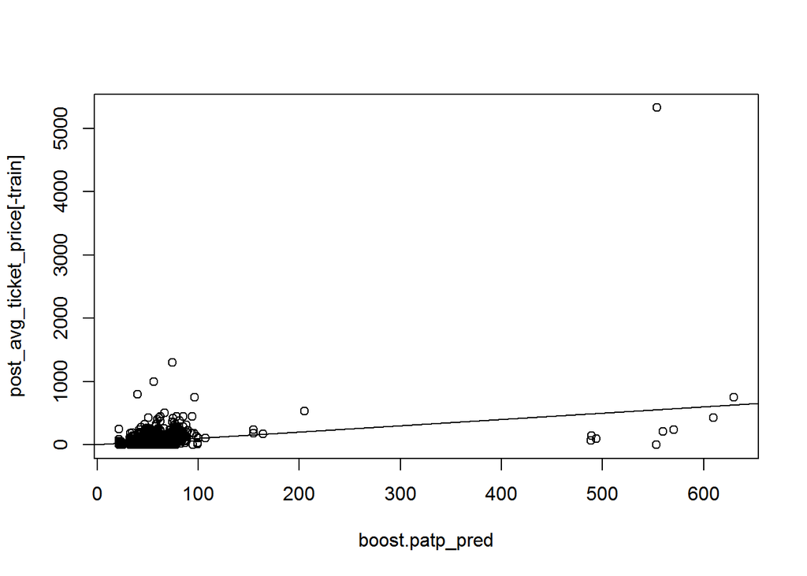

```r
#Growing Tree
boost.patp_train <- gbm(post_avg_ticket_price~., data=dataset.patpB[train,], distribution='gaussian', n.trees=1000, interaction.depth=4)
#Can't plot tree
#Fitting model on test set
boost.patp_pred <- predict(boost.patp_train, dataset.patpB[-train,], n.trees=1000)
plot(boost.patp_pred, post_avg_ticket_price[-train])
abline(0,1)
```

```r
#Mean Squared Error
MSE.boost.patp <- mean((boost.patp_pred-post_avg_ticket_price[-train])^2)
MSE.boost.patp
```

```
## [1] 16928.79
```

```r
A_methods <- rbind(A_methods, c("Boosted Tree",MSE.boost.patp))
```

```
## [1] "Test MSE is 16928.7892057868 . Root MSE is 130.110680598431 , indicating this model leads to test predictions within around 130.1 dollars of the average ticket price."
```

Looking at Most Effective Method

```r
A_methods <- A_methods[-1,]
A_methods[order(A_methods[,2],decreasing = FALSE),]
```

```
##      [,1]                   [,2]
## [1,] "Tree"                 "12644.4269476081"
## [2,] "Cross Validated Tree" "12644.4269476081"
## [3,] "Random Forest Tree"   "14651.702156979"
## [4,] "Boosted Tree"         "16928.7892057868"
## [5,] "Bagged Tree"          "18201.3976704181"
```

```r
Top <- A_methods[1,]
```

```
## [1] "The most effective method was the Tree , with 12644.4269476081 MSE."
```

Back to top